# Simple Linear Regression: Diagnostics

2024-12-15

# 1 Simulations

We assume the following simple linear regression model for the population:

$$Y = 10 + 2X + \epsilon_i.$$

In this example, we consider a sample comprising 10 observations. For each observation, the level for $X$ is fixed. We repeatedly sample an outcome for each observation from their respective conditional probability distributions for the outcome.

```r
# Initialize the population parameters and the simulation size
beta_0 <- 10
beta_1 <- 2
err_var <- 4
n <- 10
sim_size <- 20

# Initialize a vector with varying levels for the predictor
x <- seq(from = 0, to = 90, by = 10)
```

```r
# During each simulation, for each level of the predictor, sample from the
# conditional probability distribution of the response
y <- c()
for (i in 1:sim_size) y <- c(y, beta_0 + beta_1 * x + rnorm(n = n, sd = sqrt(err_var)))

# Initialize a data frame with the data for the model that holds
dat <- data.frame(x = rep(x, times = sim_size), y = y)
```

```r
# We will create a second set of data where there is a departure from the normality
# of the regression function
y <- c()
for (i in 1:sim_size) y <- c(y, beta_0 + beta_1 * x^2 + rnorm(n = n, sd = sqrt(1000)))

# Initialize a data frame with the data for the model that holds
dat_nl <- data.frame(x = rep(x, times = sim_size), y = y)
```

```r
# We will create a third set of data where there is a departure from the contancy
# of the variance
y <- c()
for (i in 1:sim_size) y <- c(y, beta_0 + beta_1 * x + rnorm(n = n, sd = ((x + 10) / 10) * sqrt(err_var)))

# Initialize a data frame with the data for the model that holds
dat_hs <- data.frame(x = rep(x, times = sim_size), y = y)
```

```r
# We will create a fourth set of data where there is a departure from the normality
# of the rror terms
y <- c()
for (i in 1:sim_size) y <- c(y, beta_0 + beta_1 * x + rnorm(n = n, sd = sqrt(err_var))^2)

# Initialize a data frame with the data for the model that holds
dat_nn <- data.frame(x = rep(x, times = sim_size), y = y)
```

# 2 Model Fitting

```r
# Fit a simple linear regression model to the data
fit <- glm(y ~ x, family = gaussian, data = dat)
```

```r
# Fit a simple linear regression model to the data
fit_nl <- glm(y ~ x, family = gaussian, data = dat_nl)
```

```r
# Fit a simple linear regression model to the data
fit_hs <- glm(y ~ x, family = gaussian, data = dat_hs)
```

```r
# Fit a simple linear regression model to the data
fit_nn <- glm(y ~ x, family = gaussian, data = dat_nn)
```

# 3 Diagnostics

## 3.1 Predictor

We perform diagnostics of the predictor to inspect the range of validity or scope and identify any potential X outliers. We can also use these diagnostics to generally get an idea of the distribution of the levels of the predictor.

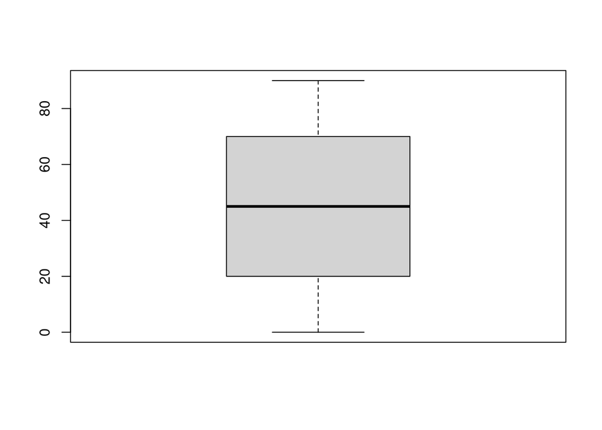

```
##
##   The decimal point is 1 digit(s) to the right of the |
##
##   0 | 00
##   2 | 00
##   4 | 00
##   6 | 00
##   8 | 00
```

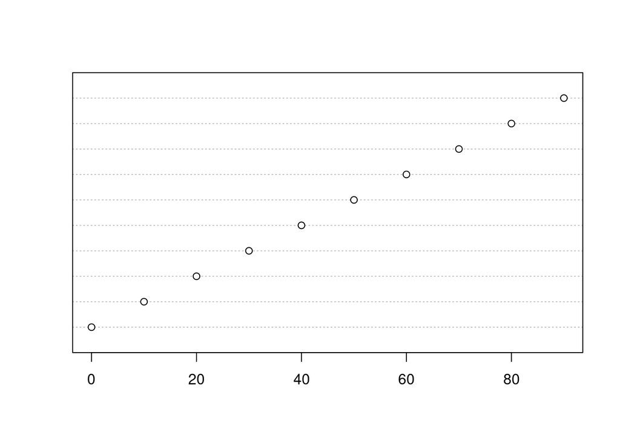

## 3.2 Residuals

Direct diagnostics for the response are not useful. Indirect diagnostics for the response via the study of the residuals is more useful. The residuals are defined as follows:

$$E_i = Y_i - \hat{Y_i}$$

The error $e_i$ is the observed error and is not the same as the true unknown error $\epsilon_i$. The errors $\epsilon_i$ are independent random variables that follow a normal distribution:

$$\epsilon_i \sim \mathcal{N}(0, \sigma^2)$$

The fact that they are independent is captured as follows:

$$Cov(\epsilon_i, \epsilon_j) = 0$$

### 3.2.1 Mean of Residuals

The mean of the observed errors is always 0:

$$\bar{E} = \frac{\sum E_i}{n}$$

```r
round(mean(fit$residuals), 5)
```

```
## [1] 0
```

```r
round(mean(fit_nl$residuals), 5)
```

```
## [1] 0
```

```r
round(mean(fit_hs$residuals), 5)
```

```
## [1] 0
```

```r
round(mean(fit_nn$residuals), 5)
```

```
## [1] 0
```

We cannot use the mean of the residuals to assess whether $E(\epsilon_i) = 0$ holds.

### 3.2.2 Variance of Residuals

The variance of the residuals is defined as follows:

$$\frac{\sum (E_i - \bar{E})^2}{n - 2} = \frac{\sum E_i^2}{n - 2} = MSE$$

The mean squared error can be used as an unbiased estimater of $\sigma^2$, the variance of the errors $\epsilon_i$.

```r
sse <- sum(fit$residuals^2)
mse <- sse / (length(x) - 2)

sse_nl <- sum(fit_nl$residuals^2)
mse_nl <- sse_nl / (length(x) - 2)

sse_hs <- sum(fit_hs$residuals^2)
mse_hs <- sse_nl / (length(x) - 2)

sse_nn <- sum(fit_nn$residuals^2)
mse_nn <- sse_nn / (length(x) - 2)
```

We obtain an $MSE = 88.51$, while we know the true error variance $\sigma^2 = 4$.

### 3.2.3 Semistudentized Residuals

The residuals can be standardized as follows:

$$e^*_i = \frac{e_i - \bar{e}}{\sqrt{MSE}} = \frac{e_i}{\sqrt{MSE}}$$

Note that we are not dividing the residuals by their own standard deviation (standard error) but by the estimator of $\sqrt{Var(\epsilon_i)}$:

$$Var(\epsilon_i) \neq Var(E_i)$$

Because we are not dividing by their standard error, the statistic $e^*_i$ is called the semistudentized residual and not the studentized residual.

## 3.3 Diagnostics for Residuals

### 3.3.1 Departure from Linearity

We have several plots available to check for a departure from linearity. We can use scatter plots, plots of residuals vs. predictor, and plots of residuals vs. fitted values.

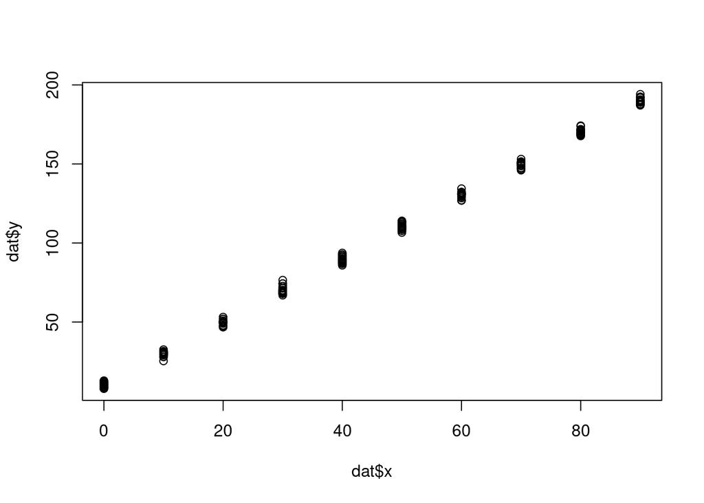

```r
plot(dat$x, dat$y)
```

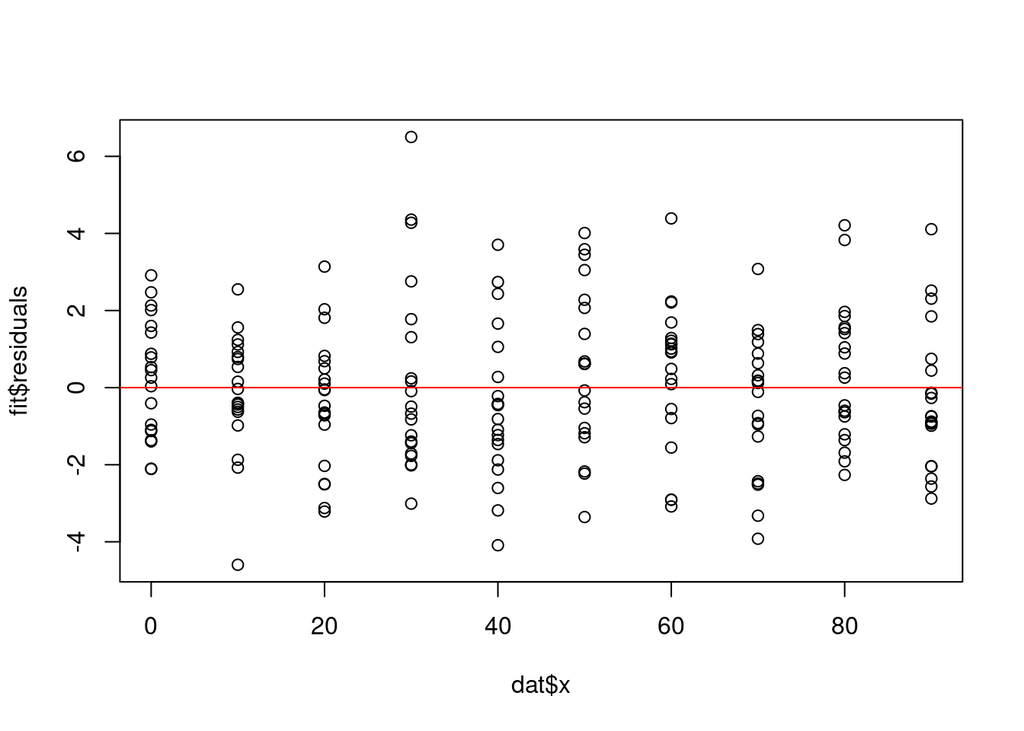

```r
plot(dat$x, fit$residuals)
abline(h = 0, col = "red")
```

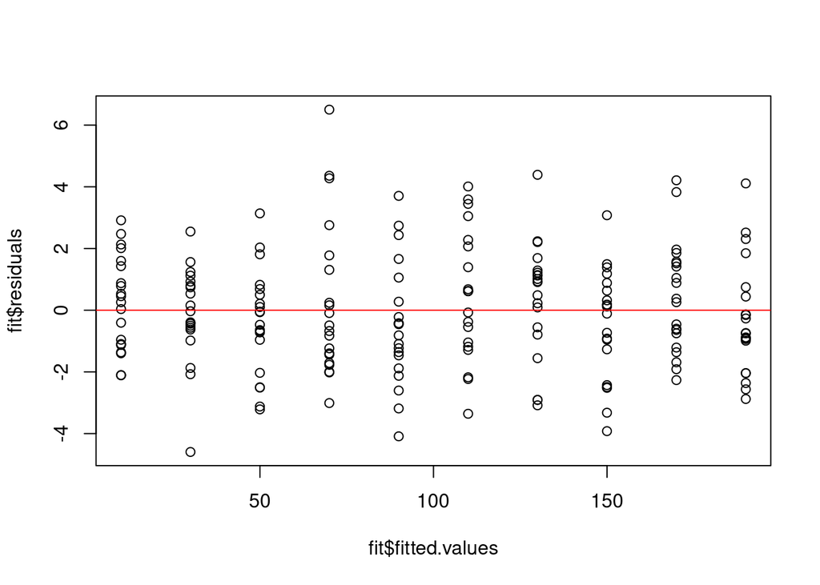

```r
plot(fit$fitted.values, fit$residuals)
abline(h = 0, col = "red")
```

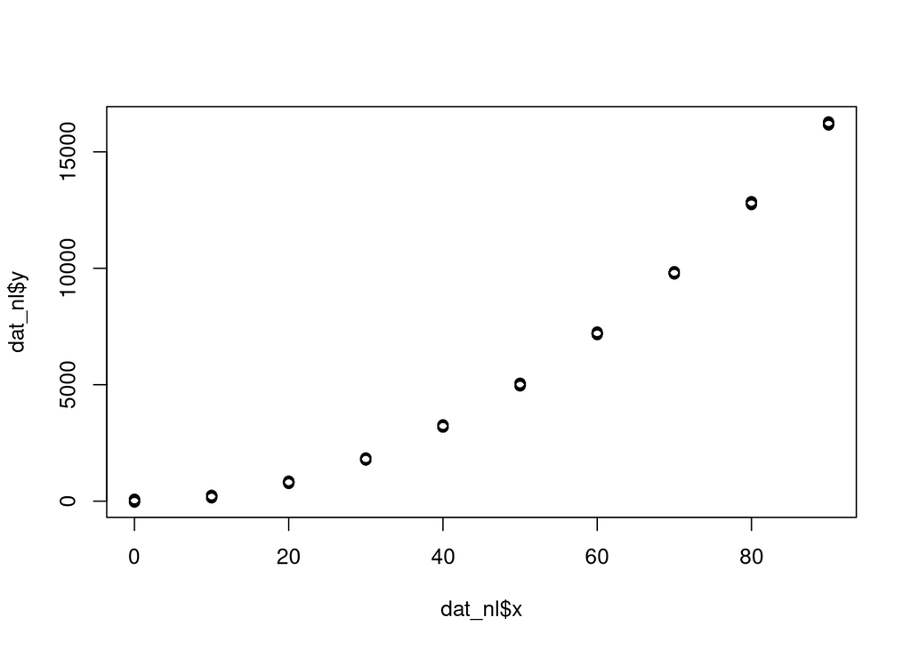

```r
plot(dat_nl$x, dat_nl$y)
```

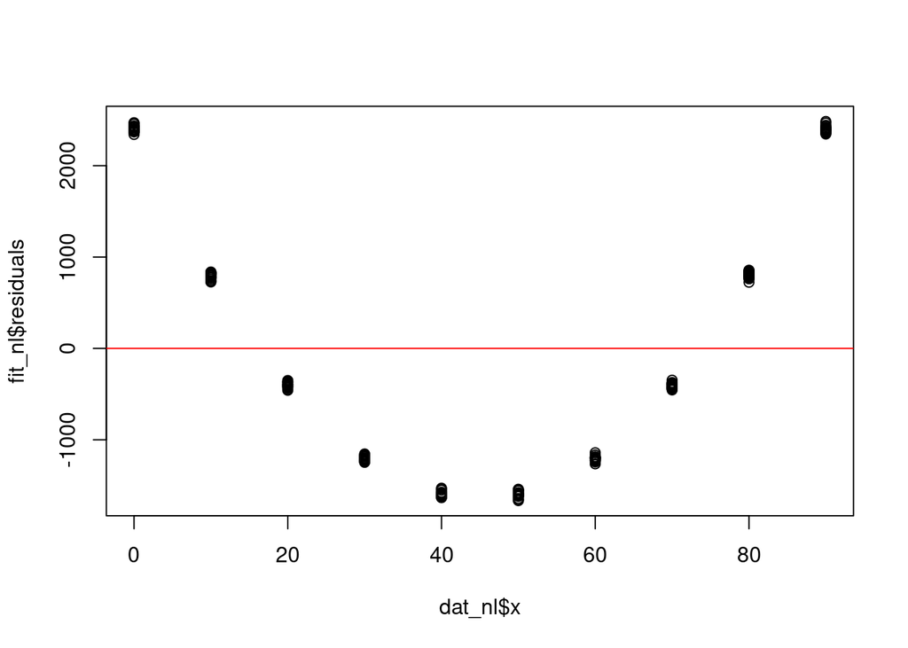

```r
plot(dat_nl$x, fit_nl$residuals)
abline(h = 0, col = "red")
```

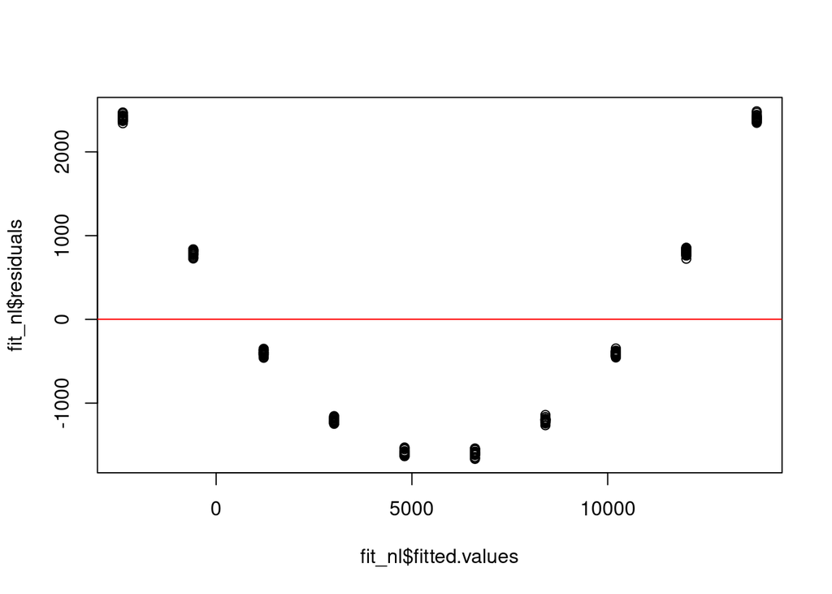

```r
plot(fit_nl$fitted.values, fit_nl$residuals)
abline(h = 2, col = "red")
```

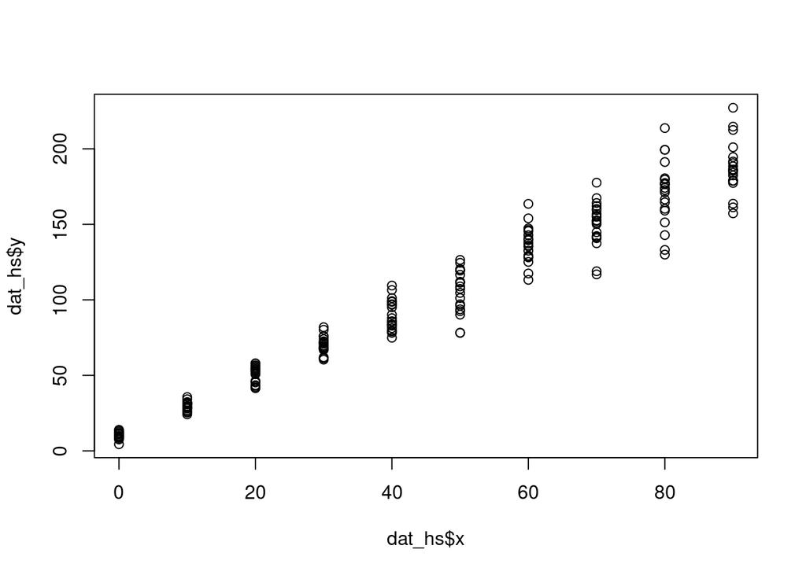

```r
plot(dat_hs$x, dat_hs$y)
```

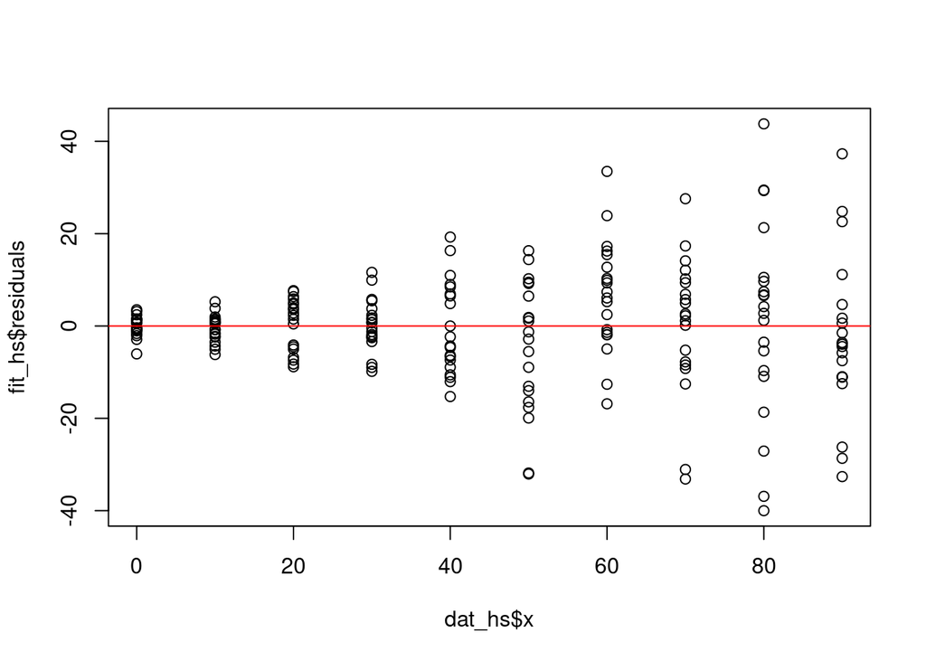

```r
plot(dat_hs$x, fit_hs$residuals)
abline(h = 0, col = "red")
```

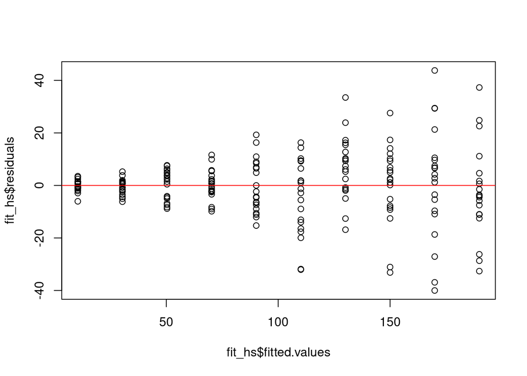

```r
plot(fit_hs$fitted.values, fit_hs$residuals)
abline(h = 0, col = "red")
```

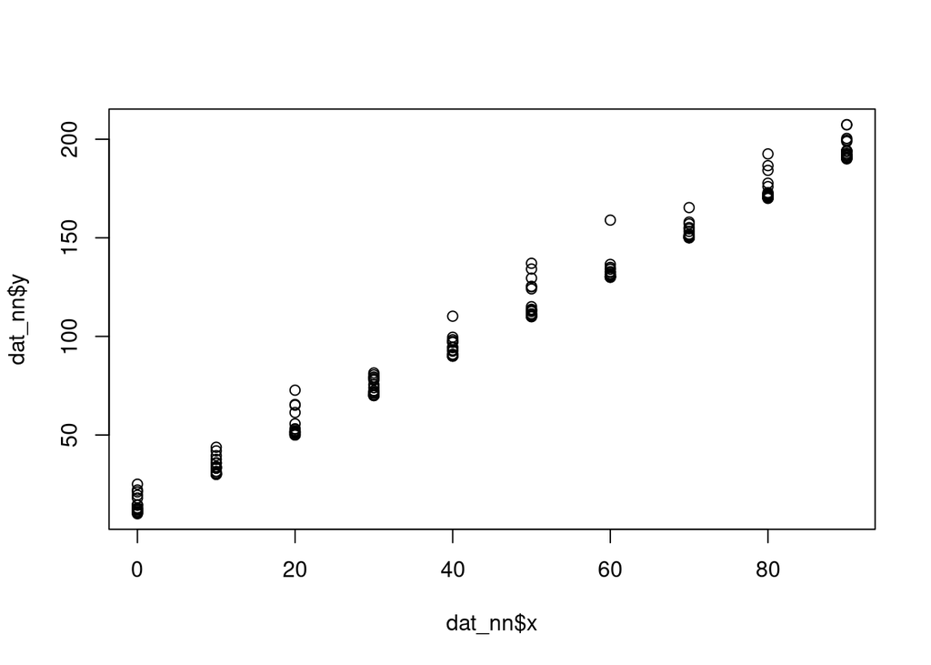

```r
plot(dat_nn$x, dat_nn$y)
```

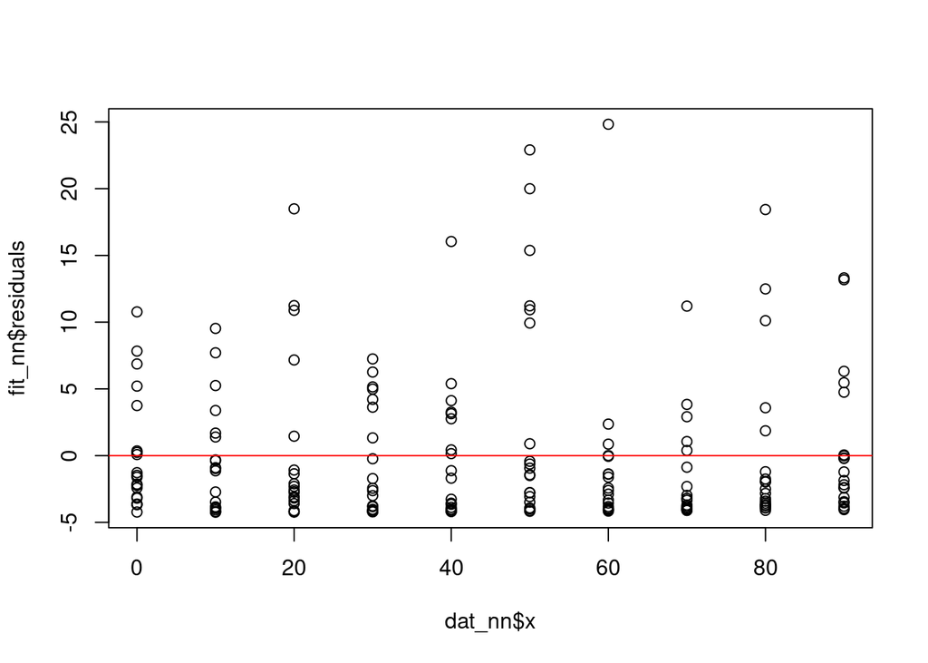

```r
plot(dat_nn$x, fit_nn$residuals)
abline(h = 0, col = "red")
```

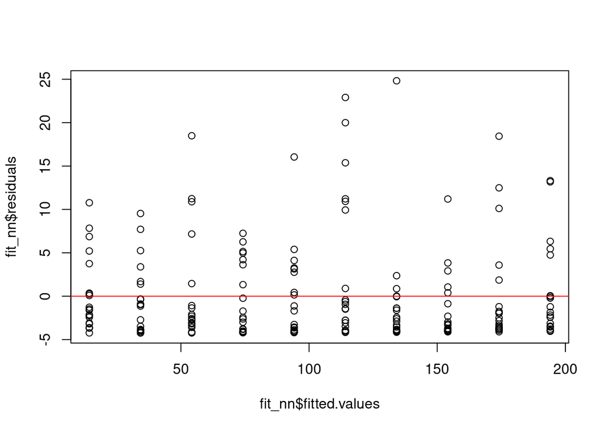

```r
plot(fit_nn$fitted.values, fit_nn$residuals)
abline(h = 0, col = "red")
```

### 3.3.2 Departure from Constancy of Variance

To investigate any departure from homoscedasticity, again, the following plots can be used:

- scatter plot of outcome as a function of predictor
- scatter plot of residuals as a function of the predictor
- scatter plot of residuals as a function of the fitted values.

To have a good view on the change in the magnitude of the error variance, without having to take into account the sign, we can square the residuals.

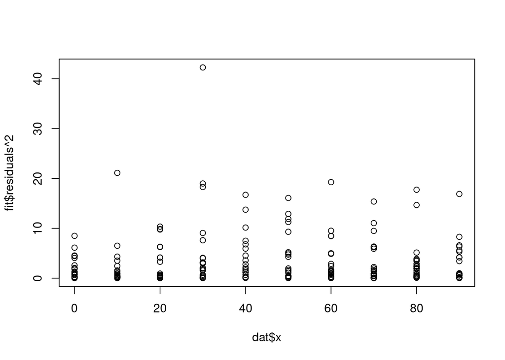

```r
plot(dat$x, fit$residuals^2)
```

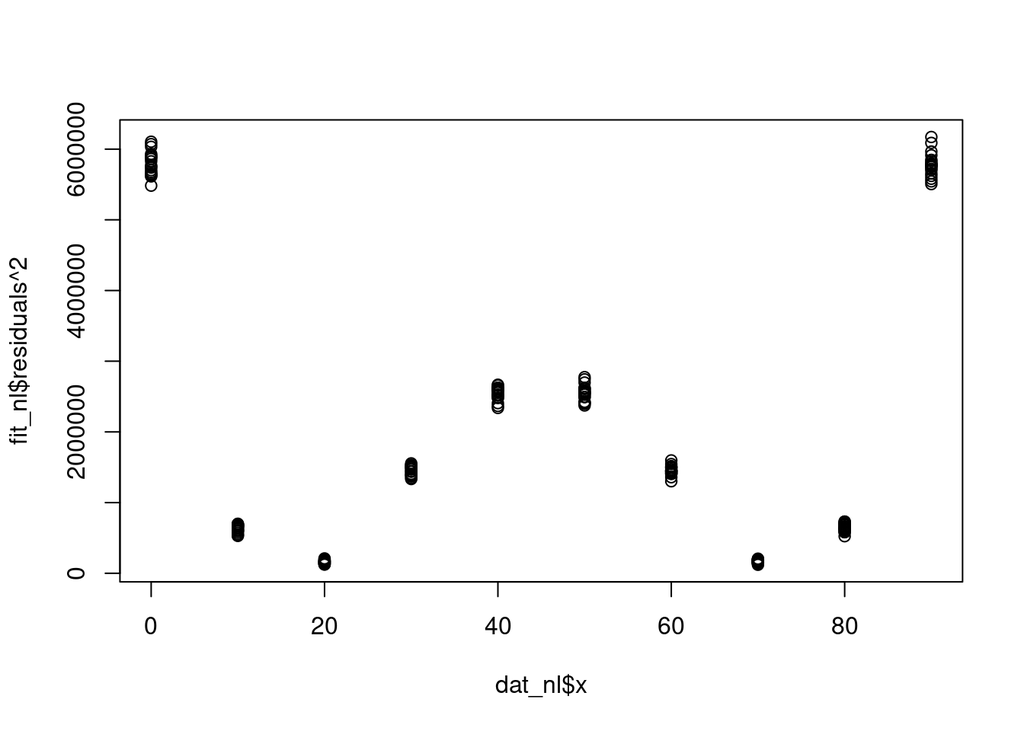

```r
plot(dat_nl$x, fit_nl$residuals^2)
```

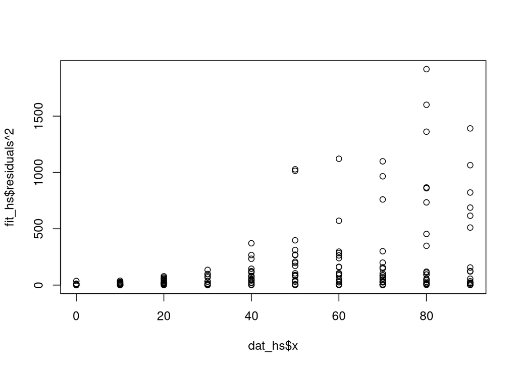

```r
plot(dat_hs$x, fit_hs$residuals^2)
```

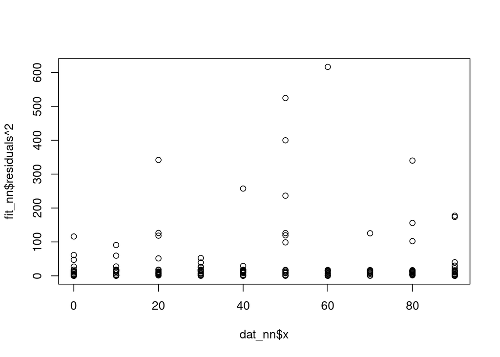

```r
plot(dat_nn$x, fit_nn$residuals^2)
```

### 3.3.3 Residual Outliers

To detect outliers it is better to use semistudentized residuals instead of the regular residuals. We can then plot the semistudentized residuals as a function of the predictor or the fitted values. As a rough rule of thumb, when the number of observations is large, is that any observations with an absolute value of the semistudentized residual larger than four is considered a residual outlier:

$$\mathopen | e^*_i \mathclose |
= \mathopen | \frac{e_i - \bar{e}}{\sqrt{MSE}} \mathclose |
= \mathopen | \frac{e_i}{\sqrt{MSE}} \mathclose | > 4$$

```r
semistudent_residuals <- fit$residuals / sqrt(mse)
semistudent_residuals_nl <- fit_nl$residuals / sqrt(mse_nl)
semistudent_residuals_hs <- fit_hs$residuals / sqrt(mse_hs)
semistudent_residuals_nn <- fit_nn$residuals / sqrt(mse_nn)
```

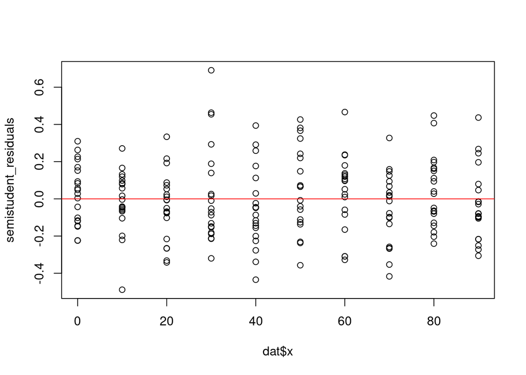

```r
plot(dat$x, semistudent_residuals)
abline(h = 0, col = "red")
```

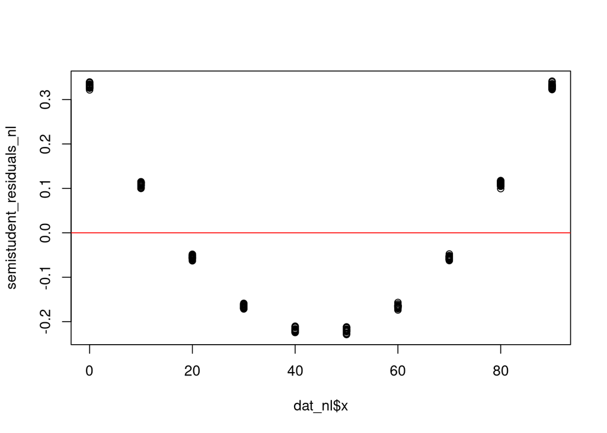

```r
plot(dat_nl$x, semistudent_residuals_nl)
abline(h = 0, col = "red")
```

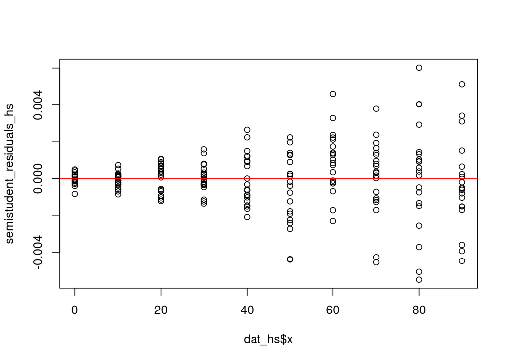

```r
plot(dat_hs$x, semistudent_residuals_hs)
abline(h = 0, col = "red")
```

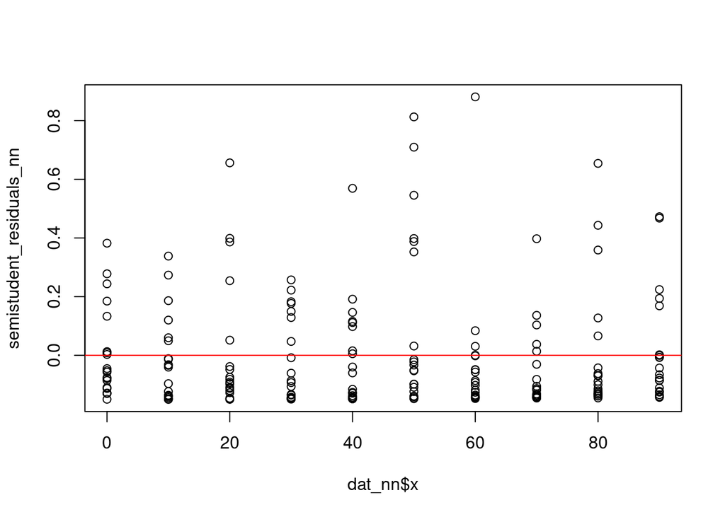

```r
plot(dat_nn$x, semistudent_residuals_nn)
abline(h = 0, col = "red")
```

### 3.3.4 Non-Independence of Errors

To detect any possible non-independence of the erros, a sequence plot of the residuals can be created. This is when there is an order in the observations, for example, when it concerns measurements taken over a period of time (time sequence) or taken over different countries in a particular order (geographical sequence).

### 3.3.5 Non-Normality of Errors

Small departures from normality are not of that of a concern, but large departures can cause trouble.

Distribution plots can be helpful in assessing normality of the errors. A box plot can help us in assessing the symmetry of the distribution and identifying any possible outliers.

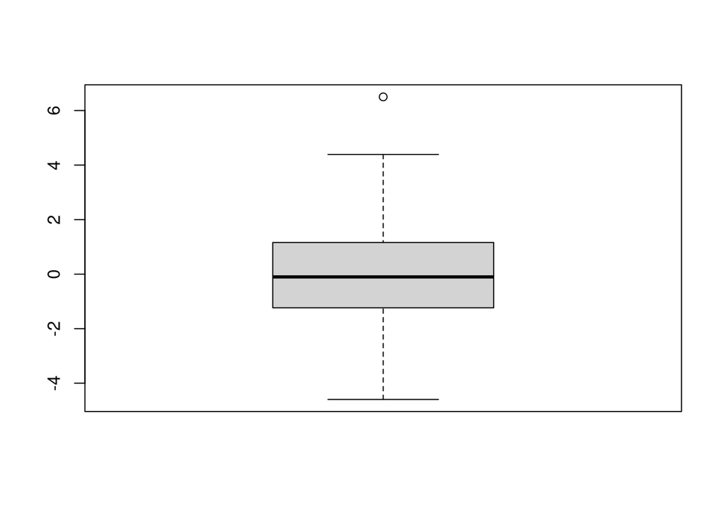

```r
boxplot(fit$residuals)
```

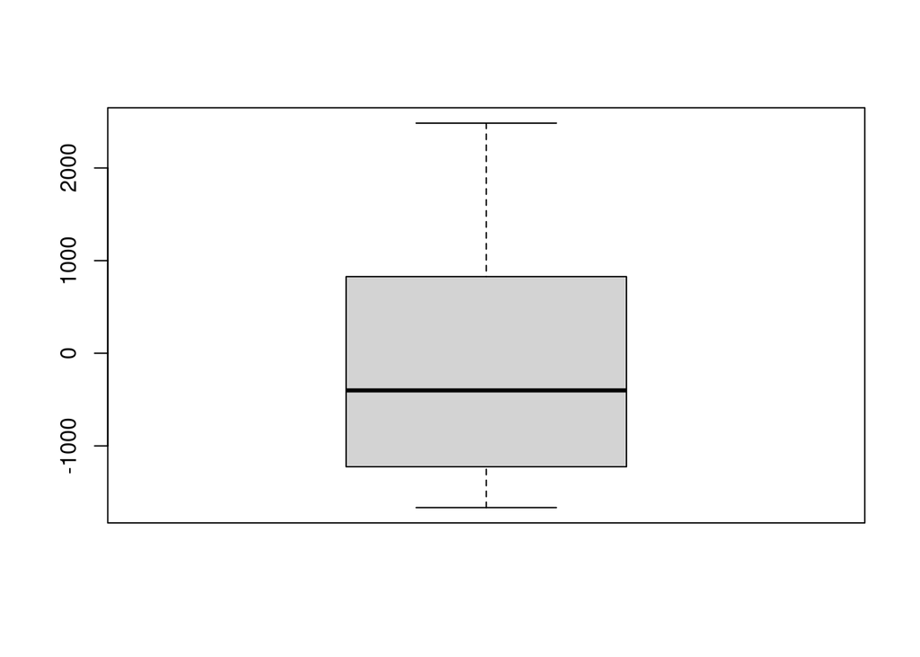

```r
boxplot(fit_nl$residuals)
```

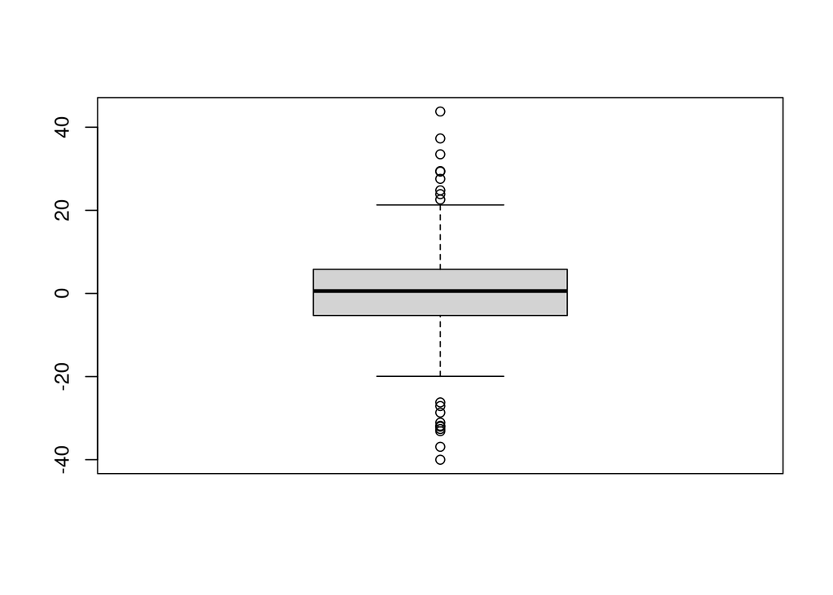

```r
boxplot(fit_hs$residuals)
```

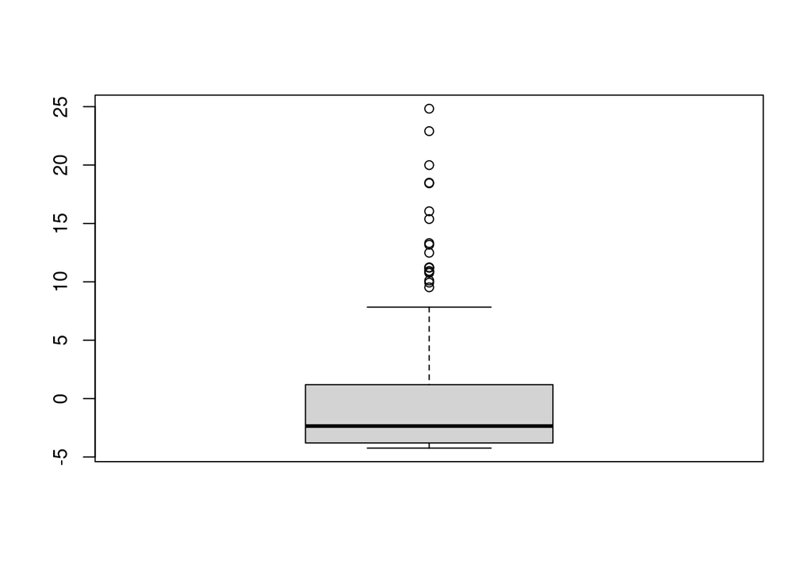

```r
boxplot(fit_nn$residuals)
```

We can also create QQ plots to assess normality of errors.

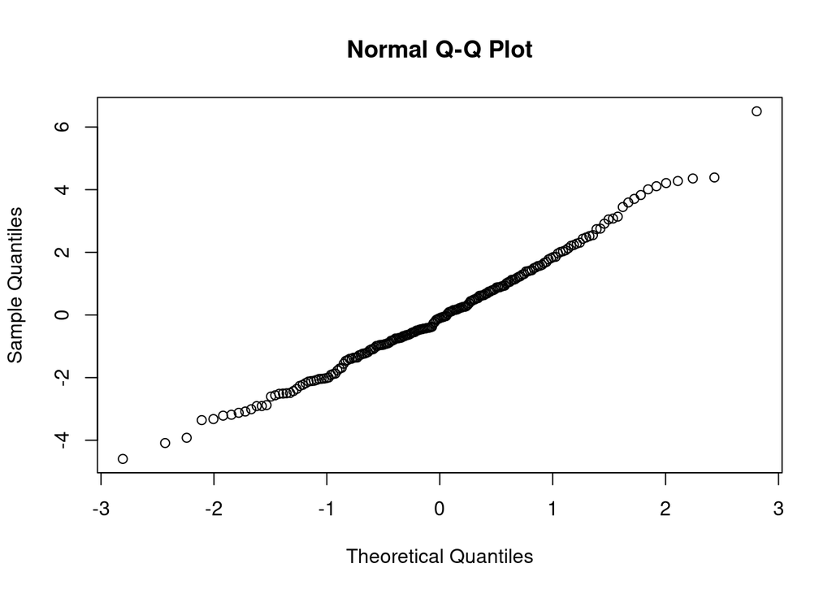

```r
qqnorm(fit$residuals)
```

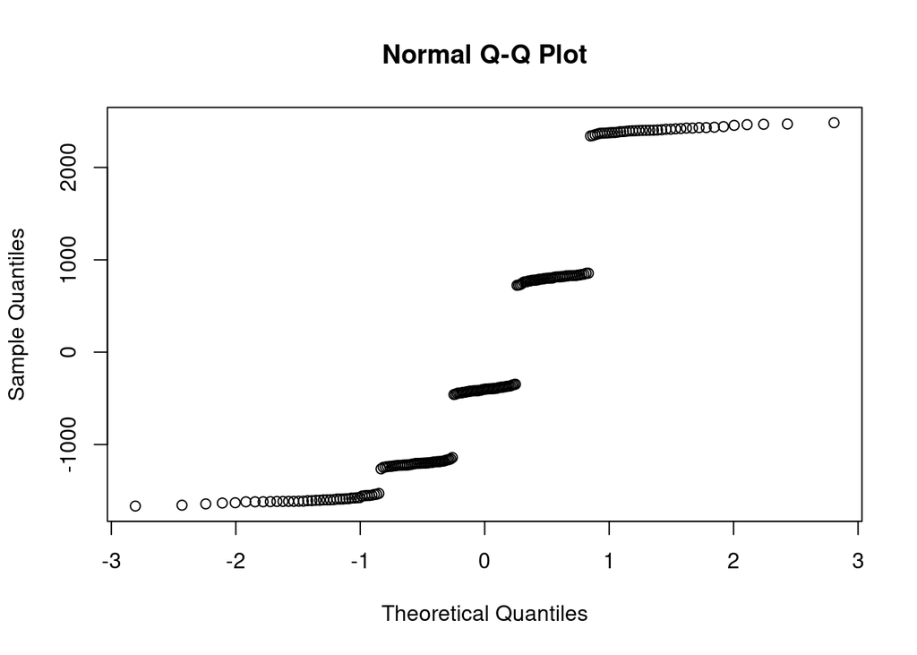

```r
qqnorm(fit_nl$residuals)
```

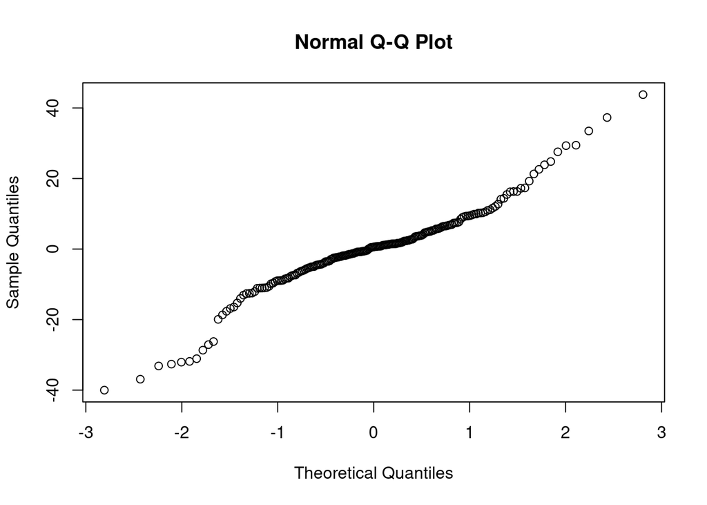

```r
qqnorm(fit_hs$residuals)
```

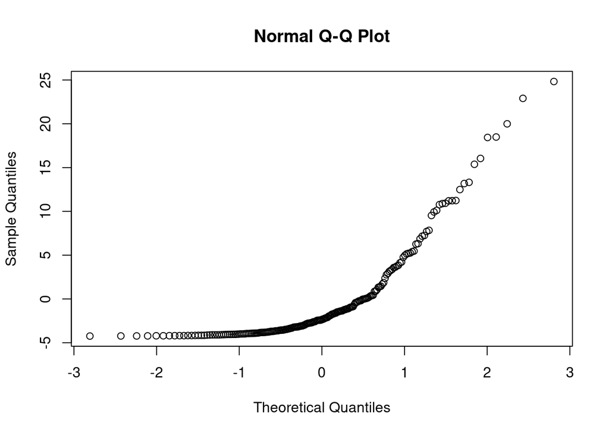

```r
qqnorm(fit_nn$residuals)
```

In relation to inferences on $\beta_0$ and $\beta_1$. If there is a slight departure from normality in the conditional probability distributions of $Y$, then this does not affect the sampling distributions of $B_0$ and $B_1$. Their sampling distributions are still normal. If, however, the departure from normality of the conditional probability distributions of $Y$ is quite strong, this will affect the sampling distributions of $B_0$ and $B_1$, unless the sample sizes are quite large, as these sampling distributions are asymptotically normal.